# Apresentação

### Thiago Kuma

#### - Cientista de Dados na Loggi

#### - Hipnólogo de entretenimento nas horas vagas

## Leitura Recomendada:

### Alberto Cairo

- Professor na Universidade de Miami
- Visualização de Dados  
  Livro [Art Introduction Information Visuzalization](https://www.amazon.com.br/Functional-Art-introduction-information-visualization-ebook/dp/B0091SXDOM?__mk_pt_BR=%C3%85M%C3%85%C5%BD%C3%95%C3%91&keywords=alberto+cairo&qid=1537789336&sr=8-2&ref=sr_1_2)

### Framework

- Base
- Escalas
- Legendas

### Visual encodings

- O mais importante
- Como dar significado aos números, ex. gráfico de barras quando colocamos proporção

### Annotations

- Texto que dá contexto
- Pode servir de introdução

[figure not shown]

### Falando em visualização de Dados e Mapa...

### Mapa VAGAS de Carreira

[Mapa de Carreira](https://www.vagas.com.br/mapa-de-carreiras/)

##### - Processamento de 10 milhões de currículos

##### - Representação baseada em grafo

##### - Representação Gênero

##### - Representação Salarial

##### - Representação das Ocupações

##### [Professora Pedagoga](https://www.vagas.com.br/mapa-de-carreiras/cargos/professora-pedagoga/0)

##### - Distribuição para demonstrar proximidade

##### [Médico](https://www.vagas.com.br/mapa-de-carreiras/cargos/medico/0)

### Vamos olhar mais tecnicamente

## Gráficos de barras

**Situação de uso**: quando queremos ter uma ideia da evolução temporal das nossas variáveis

Título: Vendas de livros de ficção  
Eixo Y: Ganhos brutos  
Eixo X: Ano

[figure not shown]

## Gráficos de linhas

**Situação de uso**: quando queremos ter uma ideia da evolução temporal contínua das nossas variáveis. Por causa disso é o plot mais comum em time series

[figure not shown]

## Scatter Plot

**Situação de uso**: quando queremos estudar a relação entre duas variáveis quantitativas

[figure not shown]

## Histogram

**Situação de uso**: analisar a distribuição de uma variável quantitativa

[figure not shown]

## Box plot

**Situação de uso**: quando queremos ter um entendimento dos momentos estatísticos básicos dos nossos dados

**Quando falha**: quando você tem muitas classes e o plot fica confuso

Como ler um boxplot:

[figure not shown]

## Treemap Chart

**Situação de uso**: quando você possui classes e clusters relativos a elas e precisa de uma foto de informação proporcional entre elas

[figure not shown]

### Primeiros Gráficos

```python
import matplotlib.pyplot as plt
```

**API do Pyplot:** [matplotlib](https://matplotlib.org/api/pyplot_api.html)

[figure not shown]

**Tutorial:** [maplotlib](https://matplotlib.org/tutorials/introductory/pyplot.html)

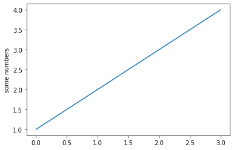

```python
plt.plot([1, 2, 3, 4])
plt.ylabel('some numbers')
plt.show()
```

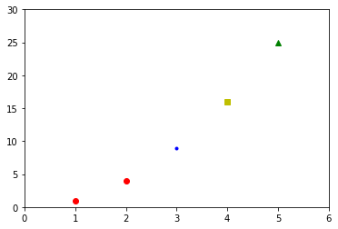

```python
plt.plot([1, 2], [1, 4], 'ro') #red circle
plt.plot([3], [9], 'b.') #blue point
plt.plot([4], [16], 'ys') #yellow square
plt.plot([5], [25], 'g^') #green triangles
plt.axis([0, 6, 0, 30])
plt.show()
```

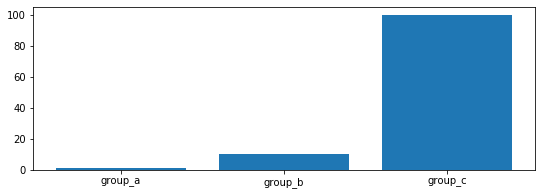

```python
names = ['group_a', 'group_b', 'group_c']
values = [1, 10, 100]

plt.figure(figsize=(9, 3))

plt.bar(names, values)
plt.show()
```

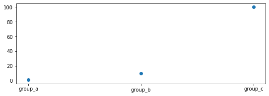

```python
names = ['group_a', 'group_b', 'group_c']
values = [1, 10, 100]

plt.figure(figsize=(9, 3))

plt.scatter(names, values)
plt.show()
```

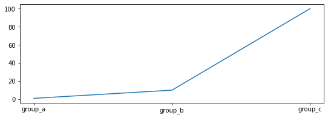

```python
names = ['group_a', 'group_b', 'group_c']
values = [1, 10, 100]

plt.figure(figsize=(9, 3))

plt.plot(names, values)
plt.show()
```

### Gráficos Mais Complexos

```python
import pandas as pd
kc = pd.read_csv(r'KingCounty_house_data.csv')
print(kc.size)
df = kc.sample(5000)
df.head()
```

```
453873
```

|  | id | date | price | bedrooms | bathrooms | sqft_living | sqft_lot | floors | waterfront | view | ... | grade | sqft_above | sqft_basement | yr_built | yr_renovated | zipcode | lat | long | sqft_living15 | sqft_lot15 |
| --- | --- | --- | --- | --- | --- | --- | --- | --- | --- | --- | --- | --- | --- | --- | --- | --- | --- | --- | --- | --- | --- |
| 9355 | 3172600031 | 20150327T000000 | 325000.0 | 3 | 1.5 | 1590 | 7936 | 1.0 | 0 | 0 | ... | 7 | 1590 | 0 | 1956 | 0 | 98106 | 47.5201 | -122.366 | 1590 | 7936 |
| 2772 | 2325069117 | 20140805T000000 | 960000.0 | 5 | 3.5 | 4510 | 16305 | 2.0 | 0 | 0 | ... | 10 | 2820 | 1690 | 2003 | 0 | 98074 | 47.6346 | -122.011 | 4330 | 18741 |
| 16949 | 418000415 | 20150319T000000 | 191000.0 | 2 | 1.0 | 700 | 5000 | 1.0 | 0 | 0 | ... | 6 | 700 | 0 | 1952 | 0 | 98056 | 47.4927 | -122.172 | 1040 | 5200 |
| 4897 | 5648600190 | 20150429T000000 | 310000.0 | 3 | 2.5 | 1670 | 5791 | 2.0 | 0 | 0 | ... | 7 | 1670 | 0 | 1995 | 0 | 98055 | 47.4424 | -122.188 | 1610 | 6034 |
| 1965 | 8952900260 | 20140919T000000 | 375000.0 | 3 | 1.0 | 1130 | 12500 | 1.5 | 0 | 0 | ... | 7 | 1130 | 0 | 1954 | 0 | 98118 | 47.5491 | -122.268 | 2280 | 8750 |

5 rows × 21 columns

```
[]
```

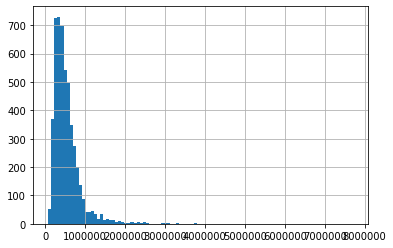

```python
df.price.hist(bins=100).plot()
# https://pandas.pydata.org/pandas-docs/stable/reference/api/pandas.DataFrame.plot.hist.html
```

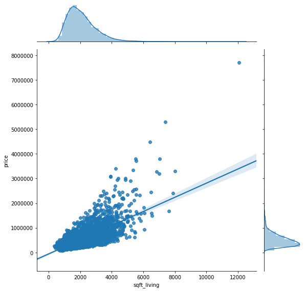

```python
import seaborn as sns
sns.jointplot(x="sqft_living", y="price", data=df, kind = 'reg',fit_reg= True, height = 8)
plt.show()
# https://seaborn.pydata.org/generated/seaborn.jointplot.html
```